# Task10

Linas Šyvis

# 1

**Sąlyga:**

For this exercise, use the price of a dozen eggs in the United States from 1900–1993 (data set eggs). Experiment with the various options in the holt() function to see how much the forecasts change with damped or exponential trend. Also try changing the parameter values for $\alpha$ and $\beta$ to see how they affect the forecasts. Try to develop an intuition of what each parameter and argument is doing to the forecasts.

[Hint: use h=100 when calling holt() so you can clearly see the differences between the various options when plotting the forecasts.]

Which model gives the best RMSE?

Do the residuals from the best model look like white noise?

```r
library(fpp)
data <- eggs
```

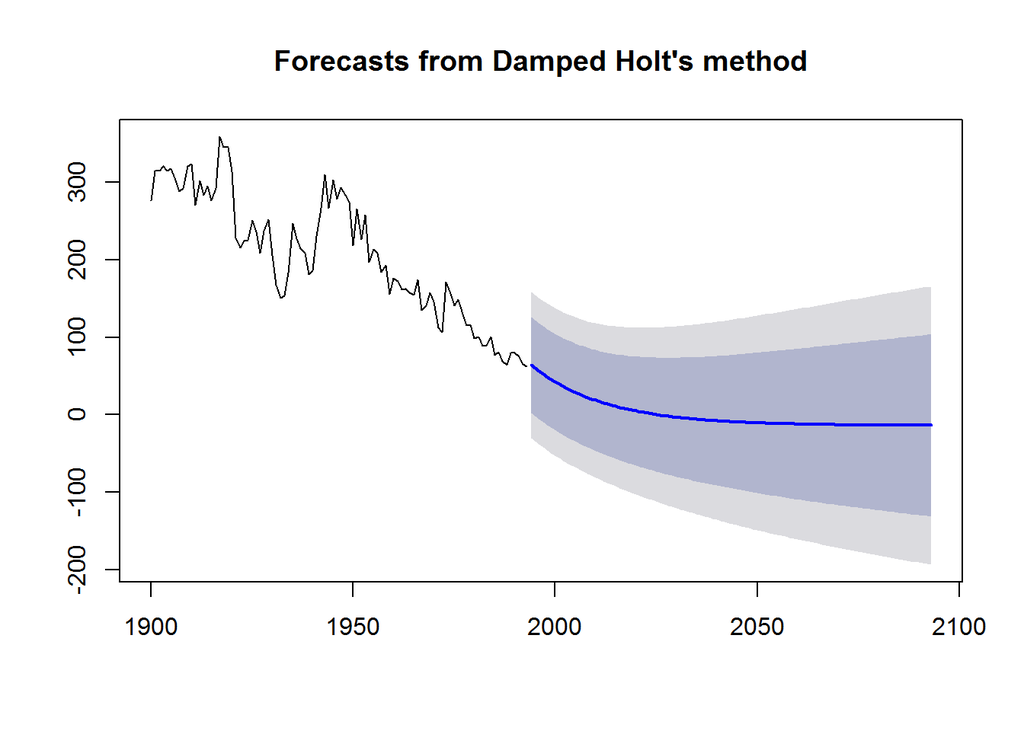

```r
fit1 <- holt(data, h=100, damped = TRUE, alpha = 0.01, beta = 0.01)
plot(fit1)
```

Matome, kad “įjungus” damped, prognozėje ilgame laikotarpyje dingsta trendas. Parametras $\alpha$ glodina modelį (kuo didesnis $\alpha$, tuo mažiau triukšmo prognozėje), o parametras $\beta$ glodina parametro $\alpha$ paveiktą prognozę (gaunasi dvigubas glodinimas).

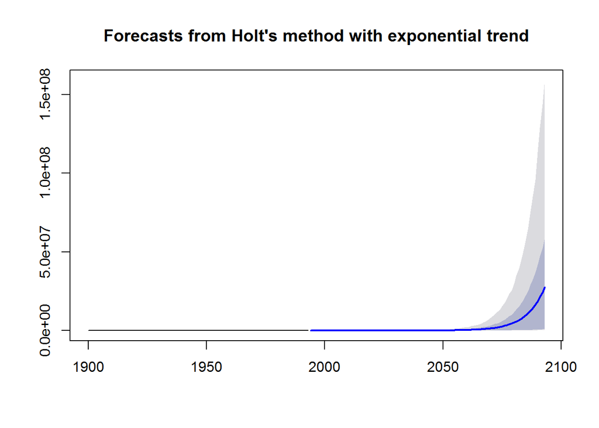

```r
fit2 <- holt(data, h=100, exponential = TRUE, alpha = 0.8, beta = 0.0001, initial = "simple")
plot(fit2)
```

Iš grafiko matome, kad modelis labai jautrus pradiniams duomenims, dėl galimo jų netikslumo išsikraipo ir visa prognozė.

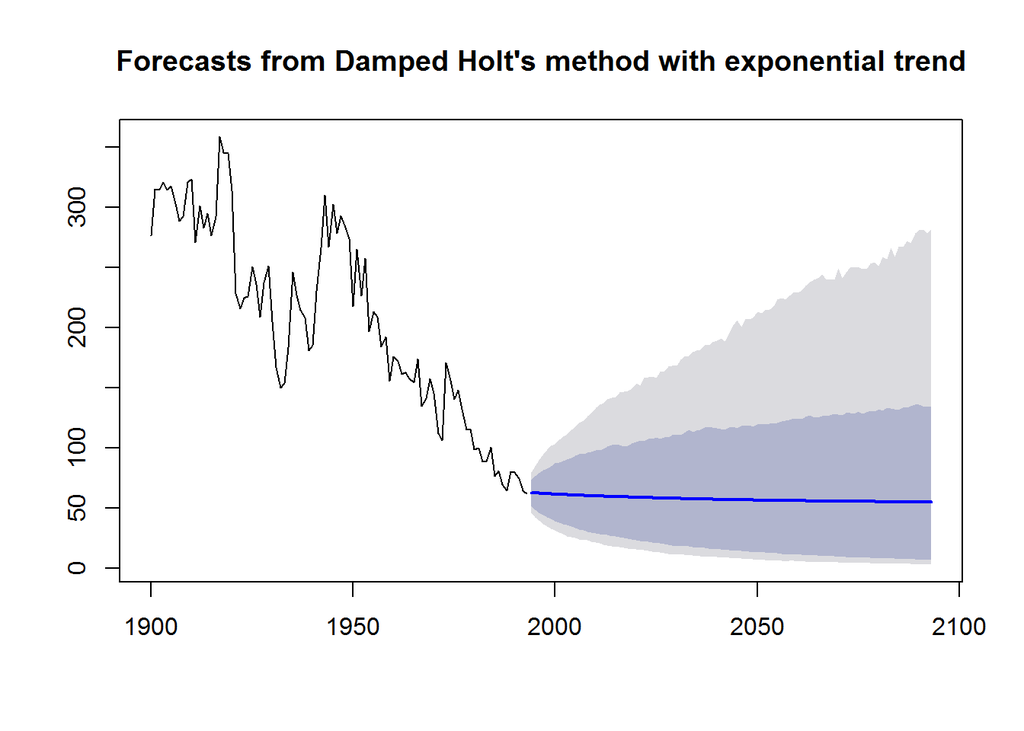

```r
fit3 <- holt(data, h=100, damped = TRUE, exponential = TRUE, alpha = 0.8, beta = 0.001)
plot(fit3)
```

Matome, kad damped panaikina duomenų trendą prognozėje, o exponential neleidžia prognozės reikšmėms būti neigiamoms. Visgi parinkus tokius parametrus, mano nuomone, iš akies negalime teigti, kad prognozė yra ganėtinai tiksli.

Palyginame modelius pagal RMSE:

```r
accuracy(fit1)
```

```
##                    ME     RMSE      MAE       MPE     MAPE     MASE
## Training set -13.1656 48.19615 39.35186 -13.57715 22.37533 1.941168
##                   ACF1
## Training set 0.8164842
```

```r
accuracy(fit2)
```

```
##                     ME     RMSE      MAE      MPE     MAPE    MASE
## Training set -40.43127 50.94198 43.07531 -21.5955 22.81149 2.12484
##                   ACF1
## Training set 0.2216502
```

```r
accuracy(fit3)
```

```
##                     ME     RMSE      MAE       MPE    MAPE      MASE
## Training set -1.065638 26.55157 19.40773 -2.232108 9.97935 0.9573544
##                    ACF1
## Training set 0.03853755
```

Matome, kad trečiojo modelio RMSE (vidutinis prognozuojamų reikšmių nuokrypis, nuo jau turimų reikšmių) yra mažiausias, todėl šiuo aspektu galime jį laikyti tiksliausią.

Patikrinkime, ar geriausiojo modelio liekanos yra baltasis triukšmas:

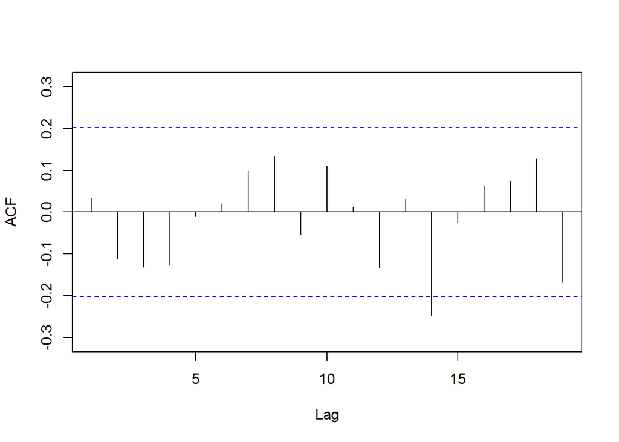

```r
Acf(fit3$res, main = "")
```

Iš grafiko matome, kad tik 14 lag’as rodo reikšmingą autokoreliaciją (kerta mėlyną punktyrinę liniją), todėl keliame hipotezę, kad liekanos yra baltasis triukšmas.

Atliksime Ljung-Box testą, su H0 hipoteze, kad duomenų liekanos yra baltasis triukšmas ir alternatyva, kad nėra.

```r
Box.test(fit3$res, type="Lj")
```

```
##
##  Box-Ljung test
##
## data:  fit3$res
## X-squared = 0.10813, df = 1, p-value = 0.7423
```

p-value > 0.05, priimame H0, vadinasi galime teigti, kad liekanos yra baltasis triukšmas.

- Išvada: pasirinkome prognozę “įjungus” ir damped, ir exponential su parametrais $\alpha = 0.8$ ir $\beta = 0.001$.

# 2

**Sąlyga:** For this exercise, use the monthly Australian short-term overseas visitors data, May 1985–April 2005. (Data set: visitors.)

1. Make a time plot of your data and describe the main features of the series.
2. Forecast the next two years using Holt-Winters’ multiplicative method.
3. Why is multiplicative seasonality necessary here?
4. Experiment with making the trend exponential and/or damped.
5. Compare the RMSE of the one-step forecasts from the various methods. Which do you prefer?
6. Check that the residuals from the best model look like white noise.

# Programos kodas

Visų pirma, įsirašome paketą {fpp}. Jame esančius duomenis naudosime užduotyje.

```r
library(fpp)
data <- visitors
```

**(a) Make a time plot of your data and describe the main features of the series.**

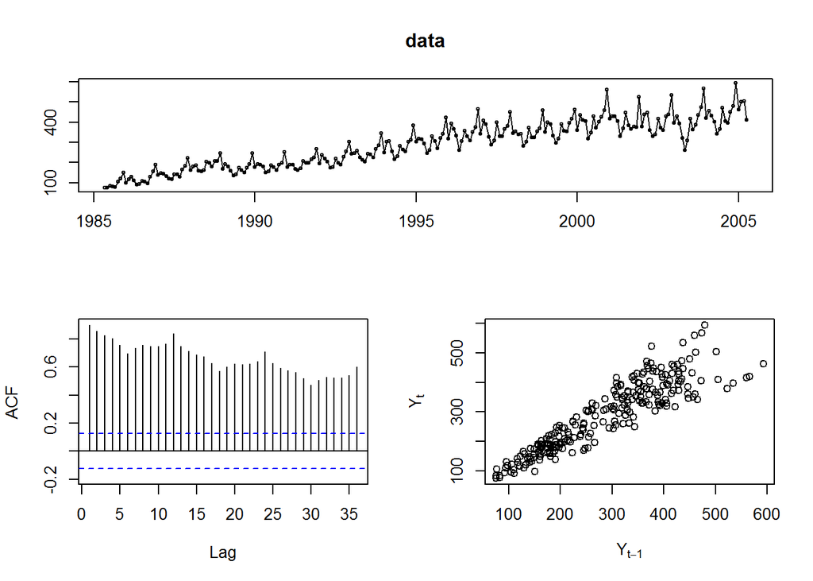

```r
tsdisplay(data, plot.type="scatter")
```

Iš pirmojo ir antrojo grafikų pastebime, kad egzistuoja sezoniškumas (periodiški kasmetiniai pakilimai ir nuosmūkiai). Iš paskutiniojo grafiko matome, kad egzistuoja stipri tiesinė priklausomybė tarp kintamojo ir jo pirmojo vėlinio.

**(b) Forecast the next two years using Holt-Winters’ multiplicative method.**

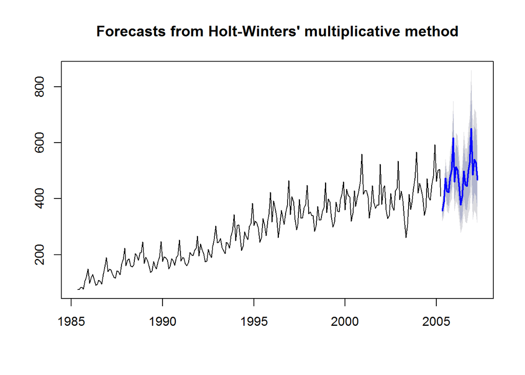

```r
fit <- hw(data, seasonal="mult", h = 24)
plot(fit)
```

**(c) Why is multiplicative seasonality necessary here?**

Multiplikatyvus sezoniškumas reikalingas, nes duomenų sezoniškumo svyravymai laikui bėgant vis didėja. Esant procentiniam pokyčiui, kai reikšmės didėja, didėja ir svyravimai.

**(d) Experiment with making the trend exponential and/or damped.**

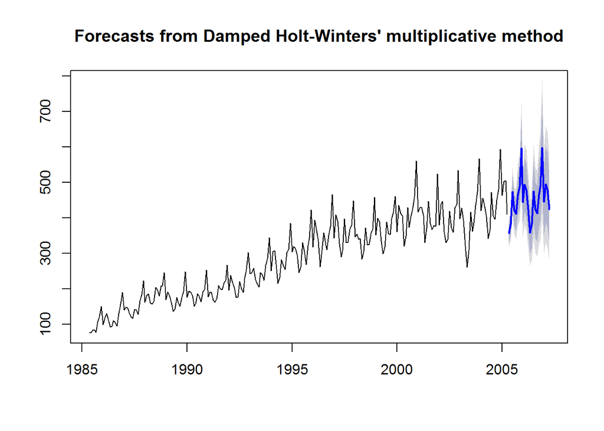

```r
fit1 <- hw(data, seasonal="mult", h = 24, damped = TRUE)
plot(fit1)
```

Padarius damped pagrindu pagrįstą prognozę, matome, kad išnyksta trendas, duomenys nebekyla, tik išlieka sezoniškumas. Padarius eksponentiniu glodinimu pagrįstą prognozę, nepastebime jokių pokyčių, todėl jos grafikai (exponential = TRUE, damped = FALSE ir exponential = TRUE, damped = TRUE) neįtraukti.

**(e) Compare the RMSE of the one-step forecasts from the various methods. Which do you prefer?**

```r
fit1 <- hw(data, seasonal="mult", h = 24)
fit2 <- hw(data, seasonal="mult", h = 24, damped = TRUE)
fit3 <- hw(data, seasonal="mult", h = 24, damped = TRUE, exponential = TRUE)
fit4 <- hw(data, seasonal="mult", h = 24, exponential = TRUE)
accuracy(fit1)
```

```
##                      ME     RMSE      MAE        MPE     MAPE      MASE
## Training set -0.8614726 14.52211 10.86884 -0.4799156 4.168399 0.4013761
##                     ACF1
## Training set -0.03448764
```

```r
accuracy(fit2)
```

```
##                    ME     RMSE      MAE       MPE     MAPE      MASE
## Training set 1.523643 14.40219 10.64283 0.3591333 4.057262 0.3930297
##                    ACF1
## Training set 0.01526565
```

```r
accuracy(fit3)
```

```
##                     ME     RMSE      MAE         MPE     MAPE      MASE
## Training set 0.5595893 14.46091 10.66091 -0.07611252 4.075176 0.3936972
##                    ACF1
## Training set -0.0268311
```

```r
accuracy(fit4)
```

```
##                      ME    RMSE      MAE        MPE     MAPE     MASE
## Training set -0.6175624 14.6899 11.00618 -0.3558085 4.230296 0.406448
##                    ACF1
## Training set 0.08654357
```

RMSE atžvilgiu damped pagrindu pagrįsta prognozė yra geriausia, nes paklaida mažiausia.

**(f) Check that the residuals from the best model look like white noise.**

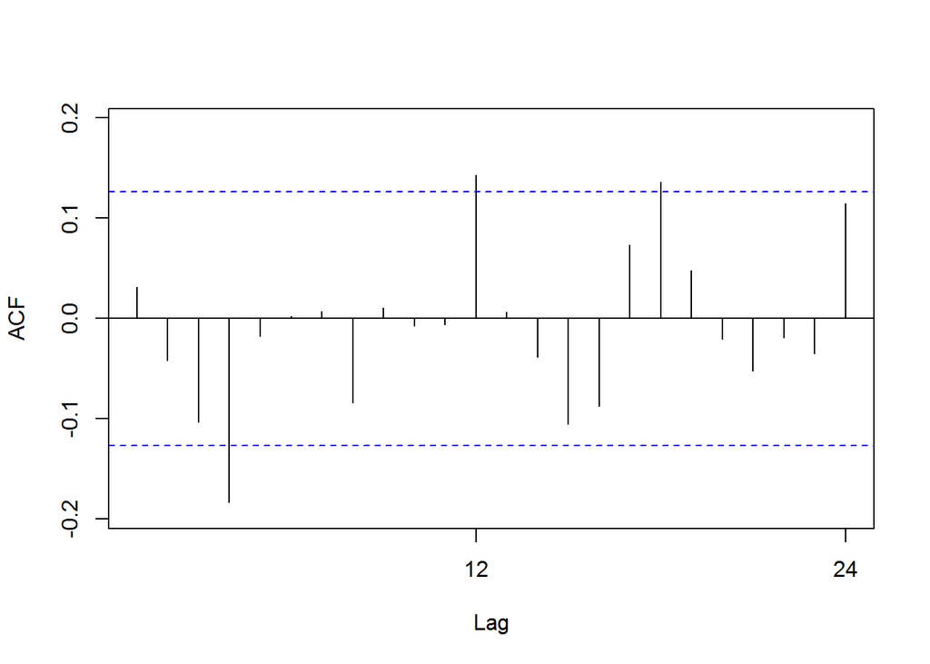

```r
Acf(fit2$res, main = "")
```

Iš grafiko galime pastebėti, kad tik trys vietos rodo reikšmingą autokoreliaciją. Todėl galime kelti hipotezę, kad liekanos yra baltasis triukšmas.

```r
Box.test(fit2$res)
```

```
##
##  Box-Pierce test
##
## data:  fit2$res
## X-squared = 0.23361, df = 1, p-value = 0.6289
```

p-value > 0.05, priimame H0, vadinasi galime teigti, kad liekanos yra baltasis triukšmas.

- Išvada: išsirinkome damped pagrindu pagrįstą prognozę, galime teigti, kad ji yra gana tiksli, nes rezultatai rodo, kad liekanos yra baltasis triukšmas.